# U2L7 - Nonlinear Regression

## Front Matter

```r
#Delete all objects from Environment - Use with caution
remove(list = ls())

#Load Libraries
library(tidyverse)
library(gridExtra)
library(ISLR2)
library(splines)
library(mgcv)
#Read in Boston Housing Data
data(Boston)
```

## Example - Polynomial Regression in R

#### Preliminary Plot

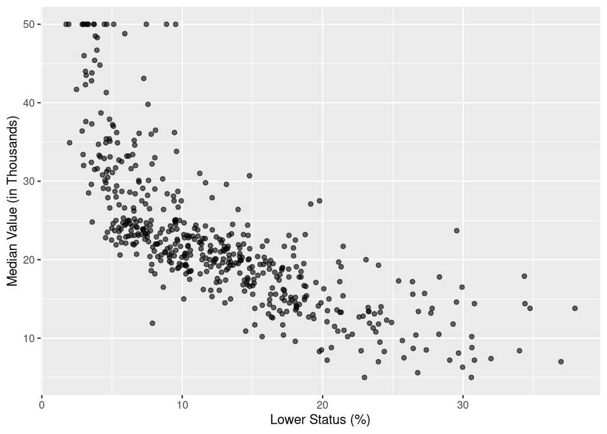

```r
#Create a plot showing the median value as a function of lower status percent. This is shown in the instructions.
ggplot(data = Boston, mapping = aes(x = lstat, y = medv)) +
  geom_point(alpha = 0.6) +
  labs(x = "Lower Status (%)",
       y = "Median Value (in Thousands)")
```

#### Part a. - Find a degree 1 (linear) model for predicting medv using lstat. Then, display a summary of the results.

```r
#Fit Linear Model
polyDeg1 <- lm(medv ~ lstat, data = Boston)

#Display a summary
summary(polyDeg1)
```

```
##
## Call:
## lm(formula = medv ~ lstat, data = Boston)
##
## Residuals:
##     Min      1Q  Median      3Q     Max
## -15.168  -3.990  -1.318   2.034  24.500
##
## Coefficients:
##             Estimate Std. Error t value Pr(>|t|)
## (Intercept) 34.55384    0.56263   61.41   <2e-16 ***
## lstat       -0.95005    0.03873  -24.53   <2e-16 ***
## ---
## Signif. codes:  0 '***' 0.001 '**' 0.01 '*' 0.05 '.' 0.1 ' ' 1
##
## Residual standard error: 6.216 on 504 degrees of freedom
## Multiple R-squared:  0.5441, Adjusted R-squared:  0.5432
## F-statistic: 601.6 on 1 and 504 DF,  p-value: < 2.2e-16
```

#### Part b. - Fit a degree 3 polynomial model for predicting medv

There are 2 approaches for fitting a degree 3 polynomial regression model.

1. You can create new variable in the dataset to represent the higher order terms.
2. You can use the `poly()` function. (For the sake of obtaining predictions on new data, this approach is easier.)

Both approaches are shown below:

```r
#Approach 1: Create variables for the second and third degree terms in the dataset

#Create new variable
Boston <-
  Boston %>%
  mutate(lstat2 = lstat^2,
         lstat3 = lstat^3)

#Build degree 3 polynomial regression function
polyDeg3 <- lm(medv ~ lstat + lstat2 + lstat3,
               data = Boston)

#Display the summary
summary(polyDeg3)
```

```
##
## Call:
## lm(formula = medv ~ lstat + lstat2 + lstat3, data = Boston)
##
## Residuals:
##      Min       1Q   Median       3Q      Max
## -14.5441  -3.7122  -0.5145   2.4846  26.4153
##
## Coefficients:
##               Estimate Std. Error t value Pr(>|t|)
## (Intercept) 48.6496253  1.4347240  33.909  < 2e-16 ***
## lstat       -3.8655928  0.3287861 -11.757  < 2e-16 ***
## lstat2       0.1487385  0.0212987   6.983 9.18e-12 ***
## lstat3      -0.0020039  0.0003997  -5.013 7.43e-07 ***
## ---
## Signif. codes:  0 '***' 0.001 '**' 0.01 '*' 0.05 '.' 0.1 ' ' 1
##
## Residual standard error: 5.396 on 502 degrees of freedom
## Multiple R-squared:  0.6578, Adjusted R-squared:  0.6558
## F-statistic: 321.7 on 3 and 502 DF,  p-value: < 2.2e-16
```

```r
#Approach 2: Particularly for higher degree polynomials, creating the extra variables can be a nuisance. Instead, use the poly() function inside of lm()

#Build degree 3 polynomial regression function
polyDeg3v2 <- lm(medv ~ poly(x = lstat, degree = 3, raw = TRUE),
                 data = Boston)

#Display the summary
summary(polyDeg3v2)
```

```
##
## Call:
## lm(formula = medv ~ poly(x = lstat, degree = 3, raw = TRUE),
##     data = Boston)
##
## Residuals:
##      Min       1Q   Median       3Q      Max
## -14.5441  -3.7122  -0.5145   2.4846  26.4153
##
## Coefficients:
##                                            Estimate Std. Error t value Pr(>|t|)
## (Intercept)                              48.6496253  1.4347240  33.909  < 2e-16
## poly(x = lstat, degree = 3, raw = TRUE)1 -3.8655928  0.3287861 -11.757  < 2e-16
## poly(x = lstat, degree = 3, raw = TRUE)2  0.1487385  0.0212987   6.983 9.18e-12
## poly(x = lstat, degree = 3, raw = TRUE)3 -0.0020039  0.0003997  -5.013 7.43e-07
##
## (Intercept)                              ***
## poly(x = lstat, degree = 3, raw = TRUE)1 ***
## poly(x = lstat, degree = 3, raw = TRUE)2 ***
## poly(x = lstat, degree = 3, raw = TRUE)3 ***
## ---
## Signif. codes:  0 '***' 0.001 '**' 0.01 '*' 0.05 '.' 0.1 ' ' 1
##
## Residual standard error: 5.396 on 502 degrees of freedom
## Multiple R-squared:  0.6578, Adjusted R-squared:  0.6558
## F-statistic: 321.7 on 3 and 502 DF,  p-value: < 2.2e-16
```

```r
#The summaries of polyDeg3 and polyDeg3v2 match which indicate the same results regardless of the approach.
```

#### Part c. - Create a plot showing the estimated cubic (degree 3 polynomial) function along with the ±2 standard deviation confidence intervals

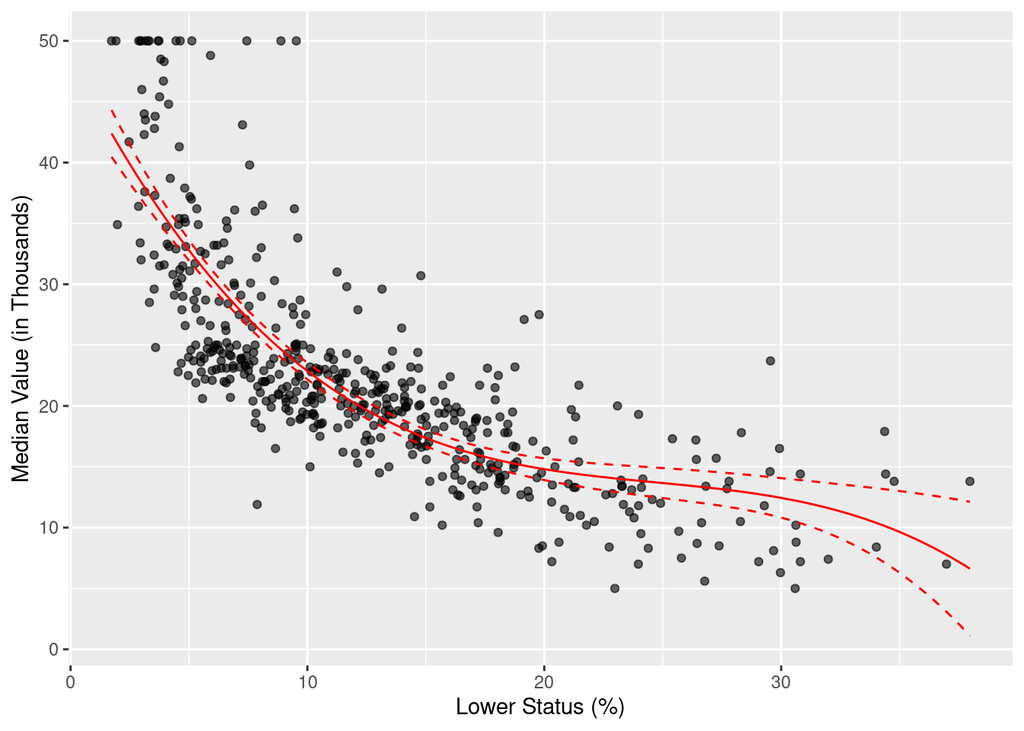

```r
#Create a dataframe contain the variables in the model and the values of the variable at which we want predictions. I will obtain predictions from the min to the max, incrementing by 0.01
predDF <- data.frame(lstat = seq(range(Boston$lstat)[1],
                                    range(Boston$lstat)[2],
                                    0.01))

#Obtain Predictions and standard errors (comes from se.fit = TRUE)
Deg3Results <- predict(polyDeg3v2,
                       newdata = predDF,
                       se.fit = TRUE)

#Calculate the Confidence intervals
predDF <-
  predDF %>%
  mutate(yhat = Deg3Results$fit,
         lb = Deg3Results$fit - 2 * Deg3Results$se.fit,
         ub = Deg3Results$fit + 2 * Deg3Results$se.fit)

#Create the plot
ggplot(data = Boston, mapping = aes(x = lstat, y = medv)) +
  geom_point(alpha = 0.6) +
  labs(x = "Lower Status (%)",
       y = "Median Value (in Thousands)") +
  geom_line(data = predDF, mapping = aes(x = lstat, y = yhat),
            color = "red") +
  geom_line(data = predDF, mapping = aes(x = lstat, y = ub),
            color = "red", linetype = "dashed") +
  geom_line(data = predDF, mapping = aes(x = lstat, y = lb),
            color = "red", linetype = "dashed")
```

#### Part d. - Is this third degree polynomial a better than the linear fit?

There are many ways to approach this question. Since we have not performed a training/validation split, I will use an indirect estimate of the test error (AIC values) to compare the model. Remember that smaller values of AIC are preferred.

```r
#Get AIC for Linear Model
AIC(polyDeg1)
```

```
## [1] 3288.975
```

```r
#Get AIC for Cubic Model
AIC(polyDeg3)
```

```
## [1] 3147.796
```

## Example - Step Functions in R

#### Use step function regression with 5 cutpoints to model medv based on lstat. Plot the results.

```r
#Create 5 evenly spaced cutpoints (which create 6 regions)
cut(Boston$lstat, breaks = (5+1)) #breaks = number of regions = cutspoints + 1
```

[output not shown]

[output cut: 71 more lines]

```r
#Determine number of properties within each region
table(cut(Boston$lstat, breaks = 6))
```

```
##
## (1.69,7.77] (7.77,13.8] (13.8,19.9] (19.9,25.9] (25.9,31.9]   (31.9,38]
##         152         161         117          45          24           7
```

```r
#Build the Step function model (just a linear regression with indicators for the regions)
step5 <- lm(medv ~ cut(lstat, 6), data = Boston)
summary(step5)
```

```
##
## Call:
## lm(formula = medv ~ cut(lstat, 6), data = Boston)
##
## Residuals:
##      Min       1Q   Median       3Q      Max
## -11.3316  -3.6072  -0.7099   2.2645  27.6913
##
## Coefficients:
##                          Estimate Std. Error t value Pr(>|t|)
## (Intercept)               31.7316     0.5000  63.467  < 2e-16 ***
## cut(lstat, 6)(7.77,13.8]  -9.4229     0.6971 -13.517  < 2e-16 ***
## cut(lstat, 6)(13.8,19.9] -14.2290     0.7581 -18.769  < 2e-16 ***
## cut(lstat, 6)(19.9,25.9] -19.0205     1.0461 -18.182  < 2e-16 ***
## cut(lstat, 6)(25.9,31.9] -19.8899     1.3539 -14.691  < 2e-16 ***
## cut(lstat, 6)(31.9,38]   -19.9173     2.3828  -8.359 6.32e-16 ***
## ---
## Signif. codes:  0 '***' 0.001 '**' 0.01 '*' 0.05 '.' 0.1 ' ' 1
##
## Residual standard error: 6.164 on 500 degrees of freedom
## Multiple R-squared:  0.5553, Adjusted R-squared:  0.5508
## F-statistic: 124.9 on 5 and 500 DF,  p-value: < 2.2e-16
```

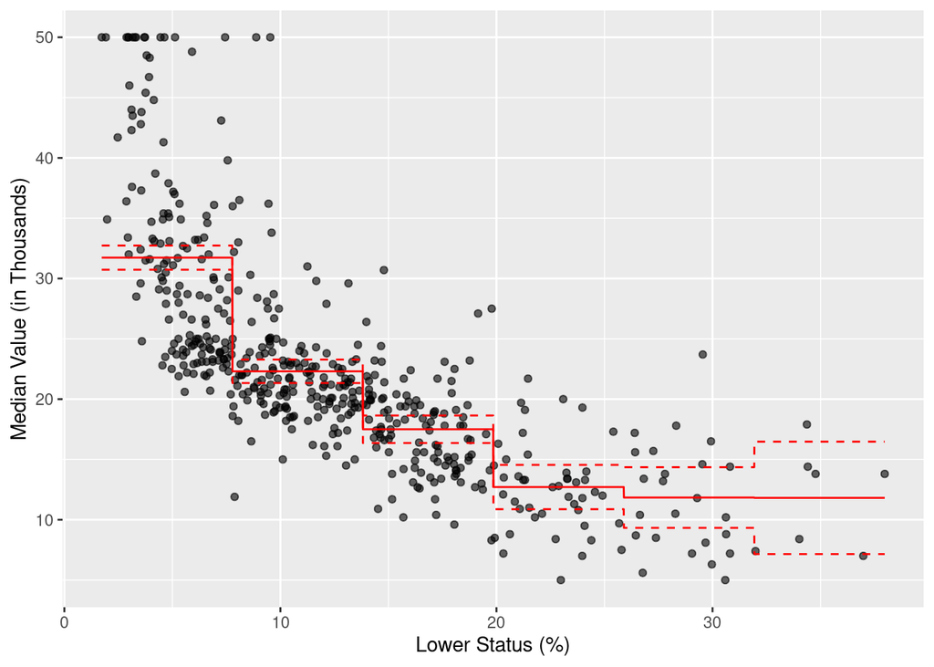

```r
#Create a dataframe contain the variables in the model and the values of the variable at which we want predictions. I will obtain predictions from the min to the max, incrementing by 0.01
predDF <- data.frame(lstat = seq(range(Boston$lstat)[1],
                                 range(Boston$lstat)[2],
                                 0.01))

#Obtain predictions and standard errors
Step5Results <- predict(step5,
                        newdata = predDF,
                        se.fit = TRUE)

#Calculate the intervals
predDF <-
  predDF %>%
  mutate(yhat = Step5Results$fit,
         lb = Step5Results$fit - 2 * Step5Results$se.fit,
         ub = Step5Results$fit + 2 * Step5Results$se.fit)

#Create the plot
ggplot(data = Boston, mapping = aes(x = lstat, y = medv)) +
  geom_point(alpha = 0.6) +
  labs(x = "Lower Status (%)",
       y = "Median Value (in Thousands)") +
  geom_line(data = predDF, mapping = aes(x = lstat, y = yhat),
            color = "red") +
  geom_line(data = predDF, mapping = aes(x = lstat, y = ub),
            color = "red", linetype = "dashed") +
  geom_line(data = predDF, mapping = aes(x = lstat, y = lb),
            color = "red", linetype = "dashed")
```

## Example - Piecewise Cubic Polynomials

```r
#Determine the Knots (using 3 evenly spaced knots correponding to the 25th, 50th, and 75th percentiles)
knots <- quantile(x = Boston$lstat, probs = c(0.25, 0.5, 0.75))

#Cubic Polynomial Region 1
CR1 <- lm(medv ~ poly(x = lstat, degree = 3, raw = TRUE),
          data = Boston[Boston$lstat <= knots[1],])

#Cubic Polynomial Region 2
CR2 <- lm(medv ~ poly(x = lstat, degree = 3, raw = TRUE),
          data = Boston[Boston$lstat > knots[1] & Boston$lstat <= knots[2],])

#Cubic Polynomial Region 3
CR3 <- lm(medv ~ poly(x = lstat, degree = 3, raw = TRUE),
          data = Boston[Boston$lstat > knots[2] & Boston$lstat <= knots[3],])

#Cubic Polynomial Region 4
CR4 <- lm(medv ~ poly(x = lstat, degree = 3, raw = TRUE),
          data = Boston[Boston$lstat > knots[3],])
```

```r
#Create a function that determines which region the observation is in and uses the region to get the predicted value
get_pred_PWcubic <- function(x, kts = knots){
  if(x <= kts[1]){
    yhat <- predict(CR1, newdata = data.frame(lstat = x))
  } else {
    if(x > kts[1] & x <= kts[2]){
      yhat <- predict(CR2, newdata = data.frame(lstat = x))
    } else {
      if(x > kts[2] & x <= kts[3]){
        yhat <- predict(CR3, newdata = data.frame(lstat = x))
      } else {
        yhat <- predict(CR4, newdata = data.frame(lstat = x))
        }
      }
    }
  return(yhat)
}
```

```r
#Create a dataframe contain the variables in the model and the values of the variable at which we want predictions. I will obtain predictions from the min to the max, incrementing by 0.01
predDF <- data.frame(lstat = seq(range(Boston$lstat)[1],
                                 range(Boston$lstat)[2],
                                 0.01))

#Obtain Predictions
predDF <-
  predDF %>%
  mutate(yhatPW = apply(predDF, 1, get_pred_PWcubic))
```

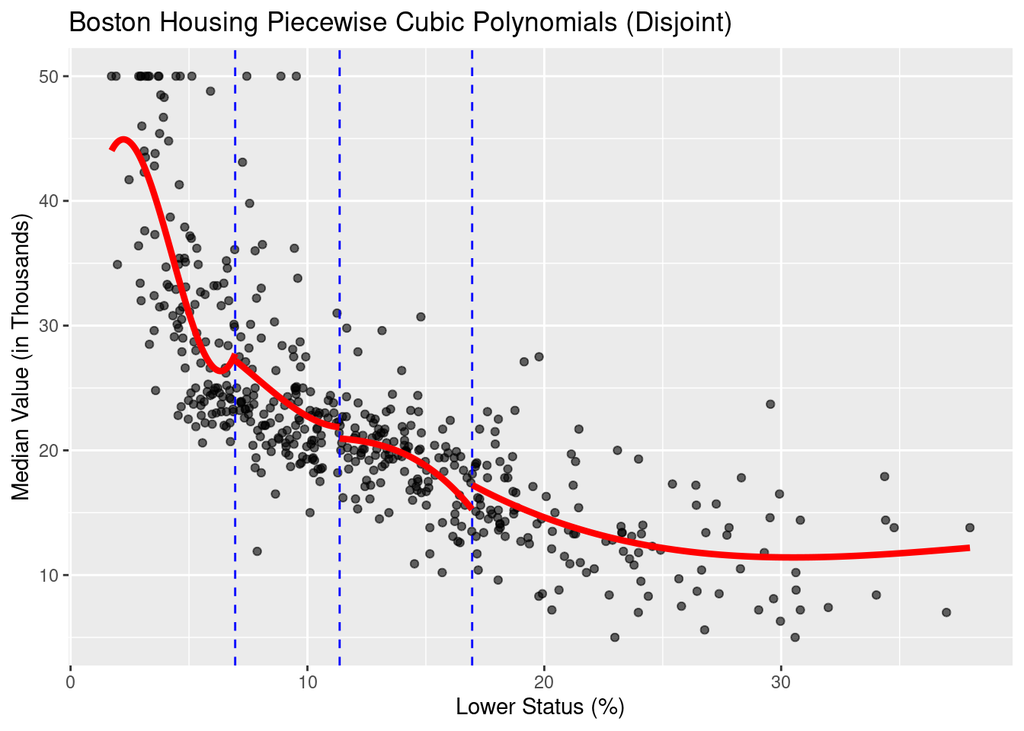

```r
#Create Piecewise Cubic Plot
mcPWCubDis <-
  ggplot(data = Boston, mapping = aes(x = lstat, y = medv)) +
  geom_point(alpha = 0.6) +
  geom_vline(xintercept = knots, color = "blue", linetype = "dashed") +
  geom_line(data = predDF[predDF$lstat <= knots[1], ],
            mapping = aes(x = lstat, y = yhatPW),
            color = "red",
            linewidth = 1.5)  +
  geom_line(data = predDF[predDF$lstat > knots[1] & predDF$lstat <= knots[2], ],
            mapping = aes(x = lstat, y = yhatPW),
            color = "red",
            linewidth = 1.5) +
  geom_line(data = predDF[predDF$lstat > knots[2] & predDF$lstat <= knots[3], ],
            mapping = aes(x = lstat, y = yhatPW),
            color = "red",
            linewidth = 1.5)  +
  geom_line(data = predDF[predDF$lstat > knots[3], ],
            mapping = aes(x = lstat, y = yhatPW),
            color = "red",
            linewidth = 1.5) +
  labs(title = "Boston Housing Piecewise Cubic Polynomials (Disjoint)",
       x = "Lower Status (%)",
       y = "Median Value (in Thousands)")

mcPWCubDis
```

## Example - Regression Splines in R

#### Part a - Find the location of the knots

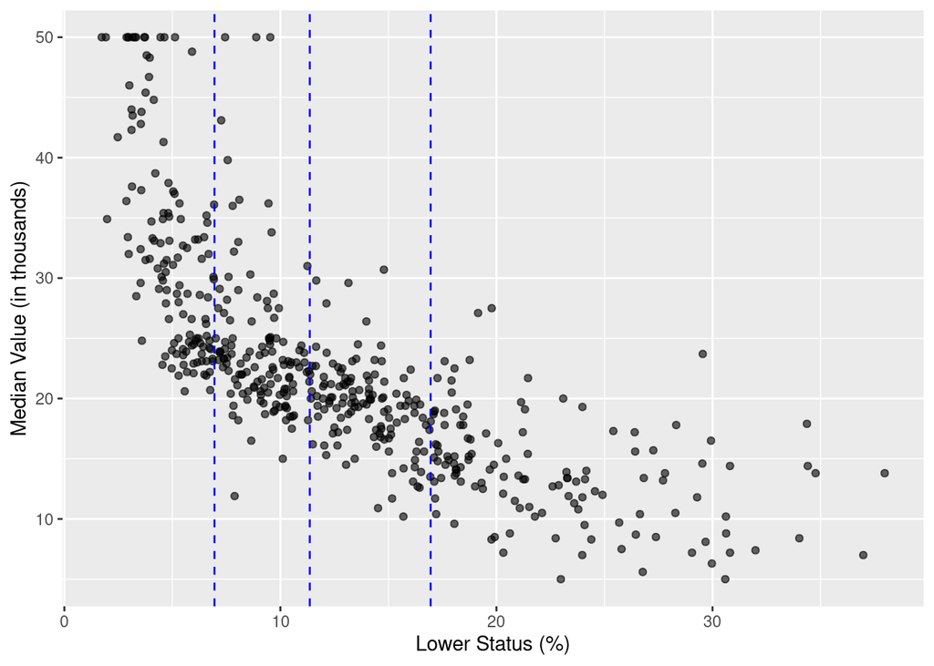

```r
#Determine the values of the knots
knots <- quantile(x = Boston$lstat,
                  probs = c(0.25, 0.5, 0.75))

#Create a plot showing the location of the knots
ggplot(data = Boston, mapping = aes(x = lstat, y = medv)) +
  geom_point(alpha = 0.6)+
  geom_vline(xintercept = knots, color = "blue", linetype="dashed") +
  labs(x = "Lower Status (%)",
       y = "Median Value (in thousands)")
```

#### Part b - How many DF for the cubic regression spline?

For each cubic polynomial, there are 4 parameters (beta0, beta1, beta2, and beta3)

Since we are fitting a cubic polynomial within each of the four regions, there are 4x4 = 16 total parameters that we must estimate

At each knot, there are 3 constraints for a cubic polynomial. Since there are 3 knots, this reduces the number of free parameters by 3 * 3 = 9

The total DF are 16 - 9 = 7

#### Part c - Fit the cubic regression spline and display a summary

```r
#Fit the cubic spline model
CubSplModel <- lm(medv ~ bs(x = lstat, degree = 3, knots = knots), data = Boston)

#Display the summary
summary(CubSplModel)
```

```
##
## Call:
## lm(formula = medv ~ bs(x = lstat, degree = 3, knots = knots),
##     data = Boston)
##
## Residuals:
##      Min       1Q   Median       3Q      Max
## -13.8071  -3.1502  -0.7389   2.1076  26.9529
##
## Coefficients:
##                                           Estimate Std. Error t value Pr(>|t|)
## (Intercept)                                 50.628      2.582  19.608  < 2e-16
## bs(x = lstat, degree = 3, knots = knots)1  -13.682      3.886  -3.521  0.00047
## bs(x = lstat, degree = 3, knots = knots)2  -26.684      2.449 -10.894  < 2e-16
## bs(x = lstat, degree = 3, knots = knots)3  -28.416      2.917  -9.743  < 2e-16
## bs(x = lstat, degree = 3, knots = knots)4  -40.092      3.050 -13.144  < 2e-16
## bs(x = lstat, degree = 3, knots = knots)5  -39.718      4.212  -9.431  < 2e-16
## bs(x = lstat, degree = 3, knots = knots)6  -38.484      4.134  -9.308  < 2e-16
##
## (Intercept)                               ***
## bs(x = lstat, degree = 3, knots = knots)1 ***
## bs(x = lstat, degree = 3, knots = knots)2 ***
## bs(x = lstat, degree = 3, knots = knots)3 ***
## bs(x = lstat, degree = 3, knots = knots)4 ***
## bs(x = lstat, degree = 3, knots = knots)5 ***
## bs(x = lstat, degree = 3, knots = knots)6 ***
## ---
## Signif. codes:  0 '***' 0.001 '**' 0.01 '*' 0.05 '.' 0.1 ' ' 1
##
## Residual standard error: 5.206 on 499 degrees of freedom
## Multiple R-squared:  0.6833, Adjusted R-squared:  0.6795
## F-statistic: 179.5 on 6 and 499 DF,  p-value: < 2.2e-16
```

#### Part d. - Create a plot showing the predictions with an approximate 95% confidence interval

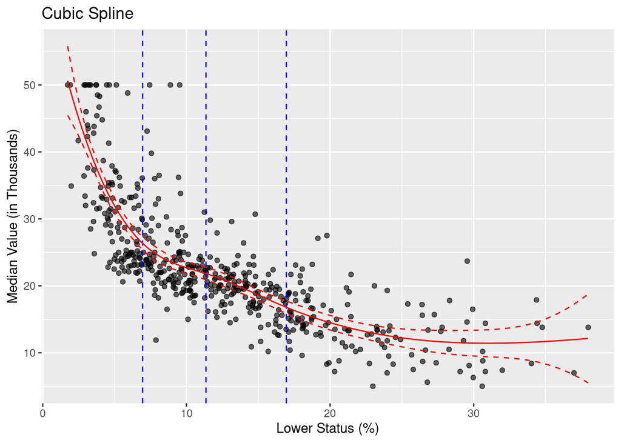

```r
#To visually depict the estimated model, start by generating a sequence of x (lstat) values for which we want to make predictions.
predDF <- data.frame(lstat=seq(min(Boston$lstat), max(Boston$lstat), 0.01))

#Obtain the predictions and the standard errors
CubSplResults <- predict(CubSplModel, newdata = predDF,
                         se.fit = TRUE)

#Calculate the intervals
predDF <- predDF %>% mutate(yhat = CubSplResults$fit,
                            lb=CubSplResults$fit - 2 * CubSplResults$se.fit,
                            ub=CubSplResults$fit + 2 * CubSplResults$se.fit,
                            )   #lb == lower bound

#Create the plot
CubSpl <-
  ggplot(data = Boston, mapping = aes(x = lstat, y = medv)) +
  geom_point(alpha = 0.6) +
  geom_vline(xintercept = knots, color = "blue",
             linetype = "dashed") +
  labs(x = "Lower Status (%)",
       y = "Median Value (in Thousands)",
       title = "Cubic Spline")+
  geom_line(data = predDF, mapping = aes(x = lstat, y = yhat), color = "red") +
  geom_line(data = predDF, mapping = aes(x = lstat, y = lb), color = "red", linetype = "dashed") +
  geom_line(data = predDF, mapping = aes(x = lstat, y = ub), color = "red", linetype = "dashed")


CubSpl
```

#### Part e - Fit the natural spline wite 4 DF

```r
#Fit the natural cubic spline model
NCubSplModel <- lm(medv ~ ns(x = lstat, df = 4), data = Boston)

#Display the summary
summary(NCubSplModel)
```

```
##
## Call:
## lm(formula = medv ~ ns(x = lstat, df = 4), data = Boston)
##
## Residuals:
##      Min       1Q   Median       3Q      Max
## -13.7909  -3.1468  -0.6878   2.1614  27.1873
##
## Coefficients:
##                        Estimate Std. Error t value Pr(>|t|)
## (Intercept)              47.734      1.285   37.15   <2e-16 ***
## ns(x = lstat, df = 4)1  -25.092      1.280  -19.61   <2e-16 ***
## ns(x = lstat, df = 4)2  -28.250      1.440  -19.61   <2e-16 ***
## ns(x = lstat, df = 4)3  -58.017      3.089  -18.78   <2e-16 ***
## ns(x = lstat, df = 4)4  -23.539      2.079  -11.32   <2e-16 ***
## ---
## Signif. codes:  0 '***' 0.001 '**' 0.01 '*' 0.05 '.' 0.1 ' ' 1
##
## Residual standard error: 5.205 on 501 degrees of freedom
## Multiple R-squared:  0.6823, Adjusted R-squared:  0.6797
## F-statistic:   269 on 4 and 501 DF,  p-value: < 2.2e-16
```

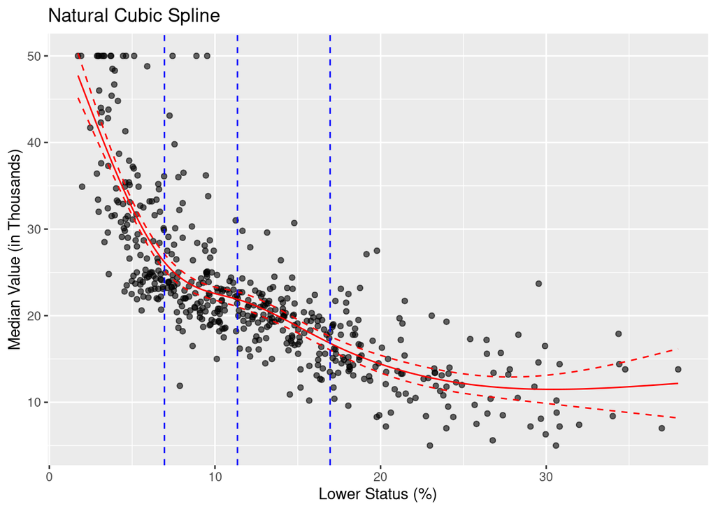

```r
#Create a dataframe contain the variables in the model and the values of the variable at which we want predictions. I will obtain predictions from the min to the max, incrementing by 0.01
predDF <- data.frame(lstat = seq(range(Boston$lstat)[1],
                                 range(Boston$lstat)[2],
                                 0.01))

#Obtain Predictions and Standard Errors
NCubSplResults <- predict(NCubSplModel,
                          newdata = predDF,
                          se.fit = TRUE)

#Calculate Intervals
predDF <-
  predDF %>%
  mutate(yhat = NCubSplResults$fit,
         lb = NCubSplResults$fit - 2 * NCubSplResults$se.fit,
         ub = NCubSplResults$fit + 2 * NCubSplResults$se.fit)

#Create Plot
NCubSpl <-
  ggplot(data = Boston, mapping = aes(x = lstat, y = medv)) +
  geom_point(alpha = 0.6) +
  labs(x = "Lower Status (%)",
       y = "Median Value (in Thousands)",
       title = "Natural Cubic Spline") +
  geom_line(data = predDF,
            mapping = aes(x = lstat, y = yhat),
            color = "red") +
  geom_line(data = predDF,
            mapping = aes(x = lstat, y = ub),
            color = "red",
            linetype = "dashed") +
  geom_line(data = predDF,
            mapping = aes(x = lstat, y = lb),
            color = "red",
            linetype = "dashed") +
  geom_vline(xintercept = knots,
             color = "blue",
             linetype = "dashed")

NCubSpl
```

#### Part e. - How does the plot of the cubic regression spline compare to that of the natural cubic?

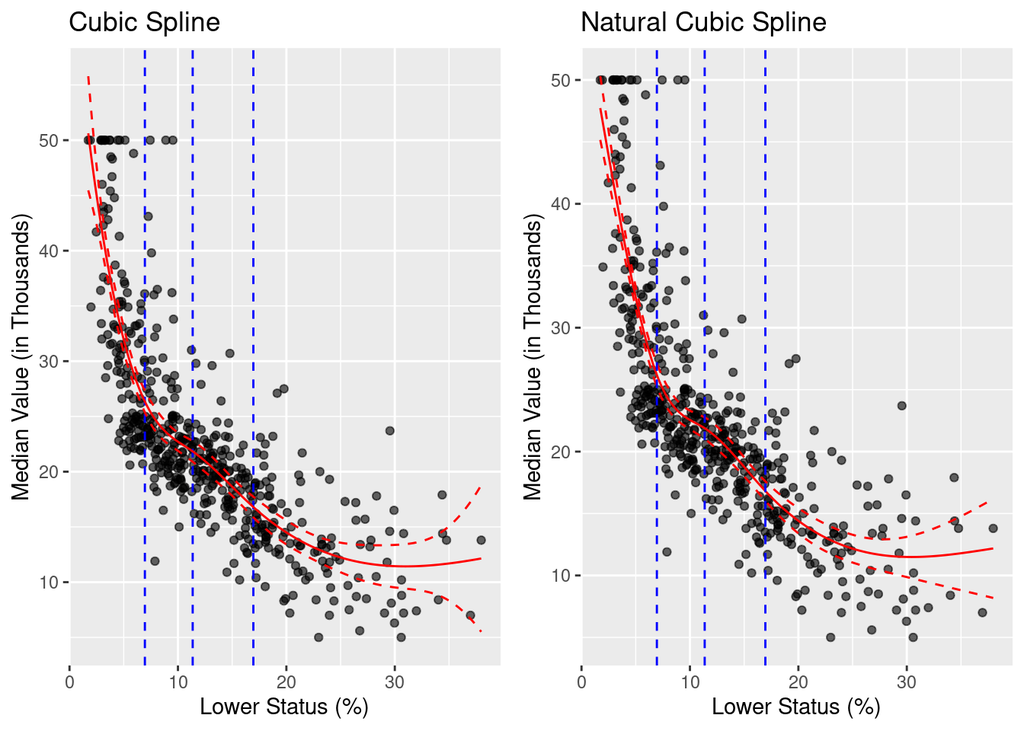

```r
#Create a plot showing the results side-by-side
grid.arrange(CubSpl, NCubSpl, ncol = 2)
```

The big difference is that the natural spline adds extra constrains in which we try to force things to be more linear near the extremes.

The consequence is that there is less variability in bounds at the extreme

## Example - Smoothing Splines in R

#### Part a. - Fit the smoothing spline model with 2 effective DF, display a summary, and create a plot

```r
#Fit a smoothing splines model with 2 effective DF
SSModel2 <- smooth.spline(x = Boston$lstat, y = Boston$medv, df = 2)

#Display a summary of the model
SSModel2
```

```
## Call:
## smooth.spline(x = Boston$lstat, y = Boston$medv, df = 2)
##
## Smoothing Parameter  spar= 1.499954  lambda= 16.41639 (29 iterations)
## Equivalent Degrees of Freedom (Df): 2.036993
## Penalized Criterion (RSS): 17483.47
## GCV: 38.32069
```

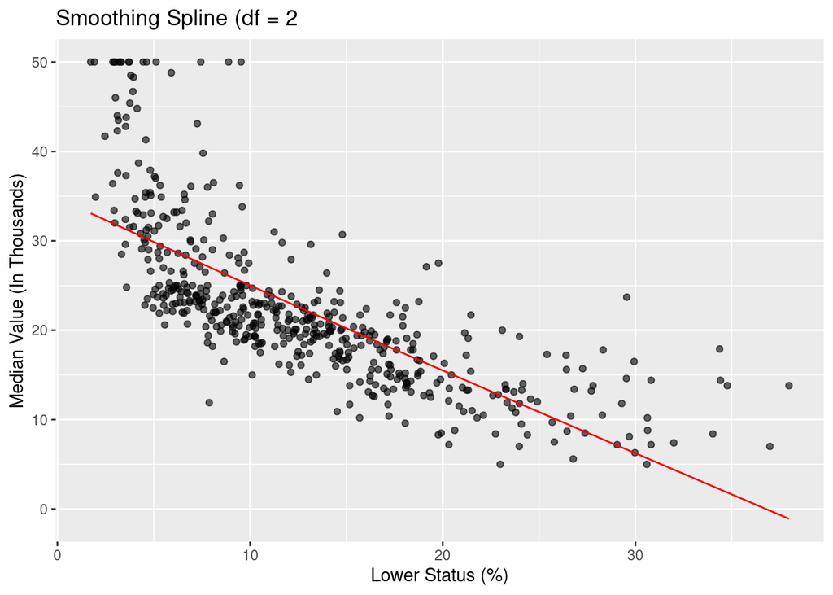

```r
#Create a dataframe contain the variables in the model and the values of the variable at which we want predictions. I will obtain predictions from the min to the max, incrementing by 0.01
predDF <- data.frame(lstat = seq(range(Boston$lstat)[1],
                                 range(Boston$lstat)[2],
                                 0.01))

#Obtain Predictions
predDF <- predDF %>% mutate(yhatSS =  as.numeric(unlist(predict(SSModel2, x = predDF)[[2]])))

#Create Plot
BosSS2 <- ggplot(data = Boston, mapping = aes(x = lstat, y = medv)) +
  geom_point(alpha = 0.6) +
  labs(x = "Lower Status (%)",
       y = "Median Value (In Thousands)",
       title = "Smoothing Spline (df = 2") +
  geom_line(data = predDF, mapping = aes(x = lstat, y = yhatSS), color = "red")

BosSS2
```

#### Part b. - Fit the smoothing splines model using LOOCV

```r
#Fit the smoothing splines model and pick lambda using LOOCV
SSModelCV <- smooth.spline(x = Boston$lstat, y = Boston$medv, cv = TRUE) # CV = TRUE means to run leave one out cross validation
#Display a summary of the model
SSModelCV
```

```
## Call:
## smooth.spline(x = Boston$lstat, y = Boston$medv, cv = TRUE)
##
## Smoothing Parameter  spar= 0.8705834  lambda= 0.0004655975 (12 iterations)
## Equivalent Degrees of Freedom (Df): 11.3742
## Penalized Criterion (RSS): 11524.64
## PRESS(l.o.o. CV): 27.38213
```

#### Part c. - Fit the smoothing splines model using generalized cross validation and create the plot

```r
#Fit the smoothing splines model and pick lambda using GCV
SSModelCV <- smooth.spline(x = Boston$lstat, y = Boston$medv, cv = FALSE) # Tell R to use GCV or generalized cross validation

#Display the summary
SSModelCV
```

```
## Call:
## smooth.spline(x = Boston$lstat, y = Boston$medv, cv = FALSE)
##
## Smoothing Parameter  spar= 0.8902443  lambda= 0.0006464526 (13 iterations)
## Equivalent Degrees of Freedom (Df): 10.5588
## Penalized Criterion (RSS): 11566.59
## GCV: 27.45311
```

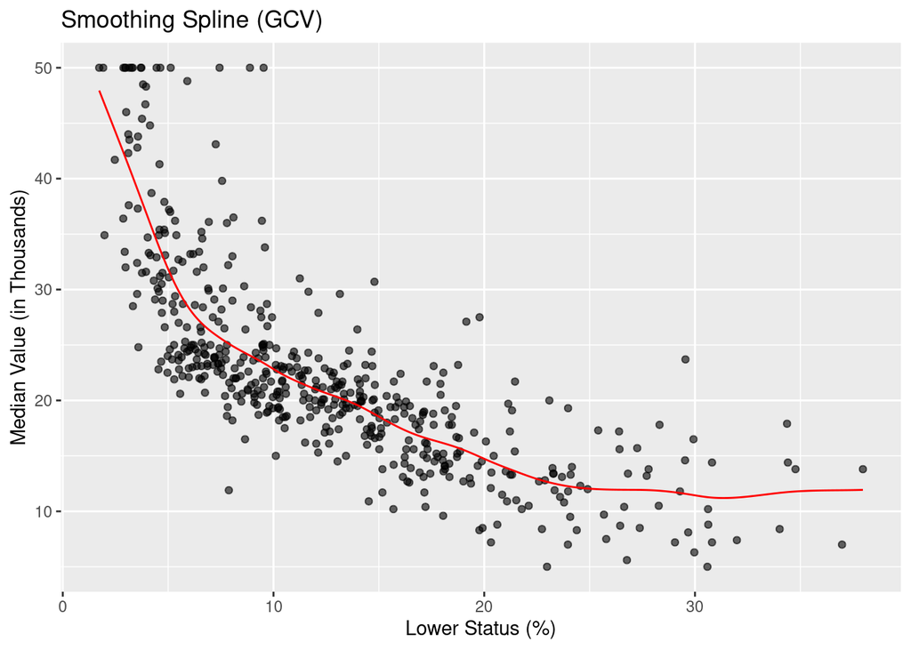

```r
#Create a dataframe contain the variables in the model and the values of the variable at which we want predictions. I will obtain predictions from the min to the max, incrementing by 0.01
predDF <- data.frame(lstat = seq(range(Boston$lstat)[1],
                                 range(Boston$lstat)[2],
                                 0.01))

#Obtain Predictions
predDF <-
  predDF %>%
  mutate(yhatSS = as.numeric(unlist(predict(SSModelCV, x = predDF)[[2]])))

#Plot Results
BosSSCV <-
  ggplot(data = Boston, mapping = aes(x = lstat, y = medv)) +
  geom_point(alpha = 0.6) +
  labs(x = "Lower Status (%)",
       y = "Median Value (in Thousands)",
       title = "Smoothing Spline (GCV)") +
  geom_line(data = predDF,
            mapping = aes(x = lstat, y = yhatSS),
            color = "red")

BosSSCV
```

#### Part c. - Compare Smoothing Splines

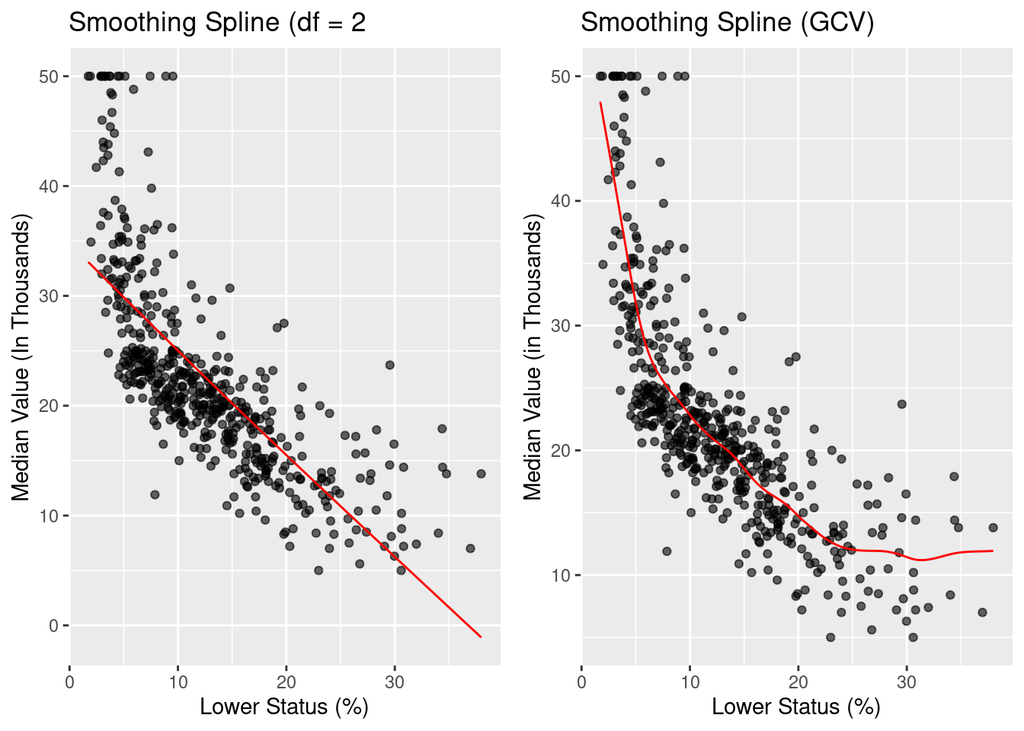

```r
grid.arrange(BosSS2, BosSSCV, ncol = 2)
```

## Example - Generalized Additive Model in R

```r
#Convert chas to a factor
Boston <-
  Boston %>%
  mutate(chasFactor = as.factor(chas))

#Build GAM
GAMmodel1 <- gam(medv ~ s(lstat) + s(indus) + chasFactor,
                 data = Boston)

#Display a summary
summary(GAMmodel1)
```

```
##
## Family: gaussian
## Link function: identity
##
## Formula:
## medv ~ s(lstat) + s(indus) + chasFactor
##
## Parametric coefficients:
##             Estimate Std. Error t value Pr(>|t|)
## (Intercept)  22.2456     0.2347  94.780  < 2e-16 ***
## chasFactor1   4.1526     0.9132   4.547 6.84e-06 ***
## ---
## Signif. codes:  0 '***' 0.001 '**' 0.01 '*' 0.05 '.' 0.1 ' ' 1
##
## Approximate significance of smooth terms:
##            edf Ref.df      F p-value
## s(lstat) 7.420  8.388 75.261  <2e-16 ***
## s(indus) 2.385  3.007  2.367  0.0702 .
## ---
## Signif. codes:  0 '***' 0.001 '**' 0.01 '*' 0.05 '.' 0.1 ' ' 1
##
## R-sq.(adj) =  0.694   Deviance explained = 70.1%
## GCV = 26.473  Scale est. = 25.855    n = 506
```

#### Part b. - Plot the contributions of each feature

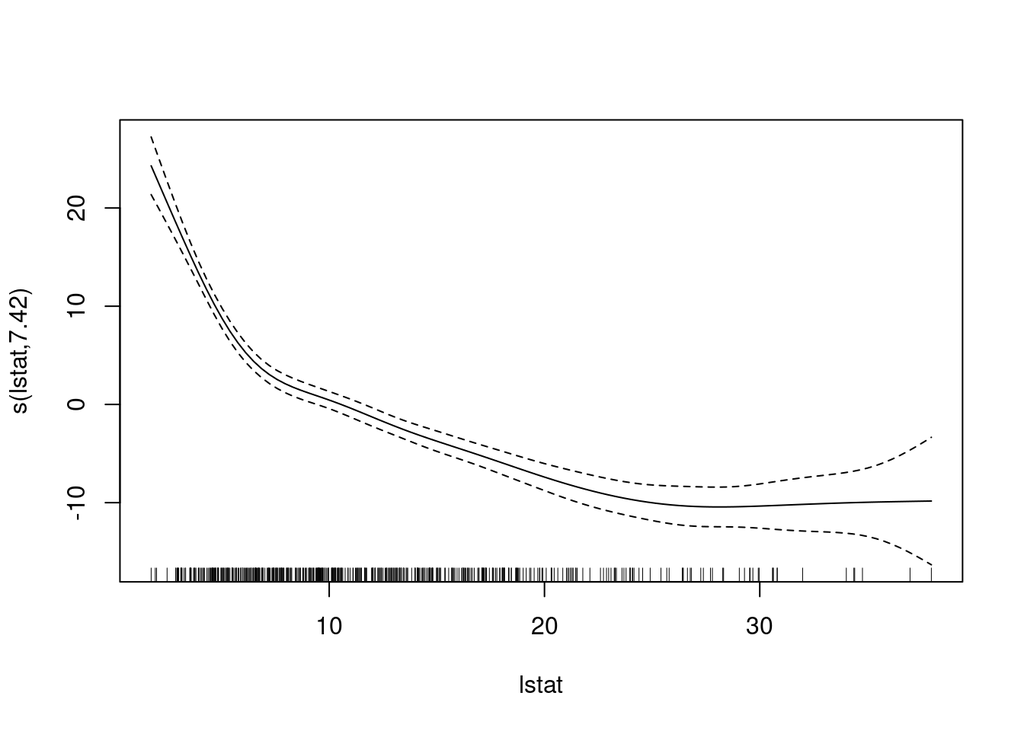

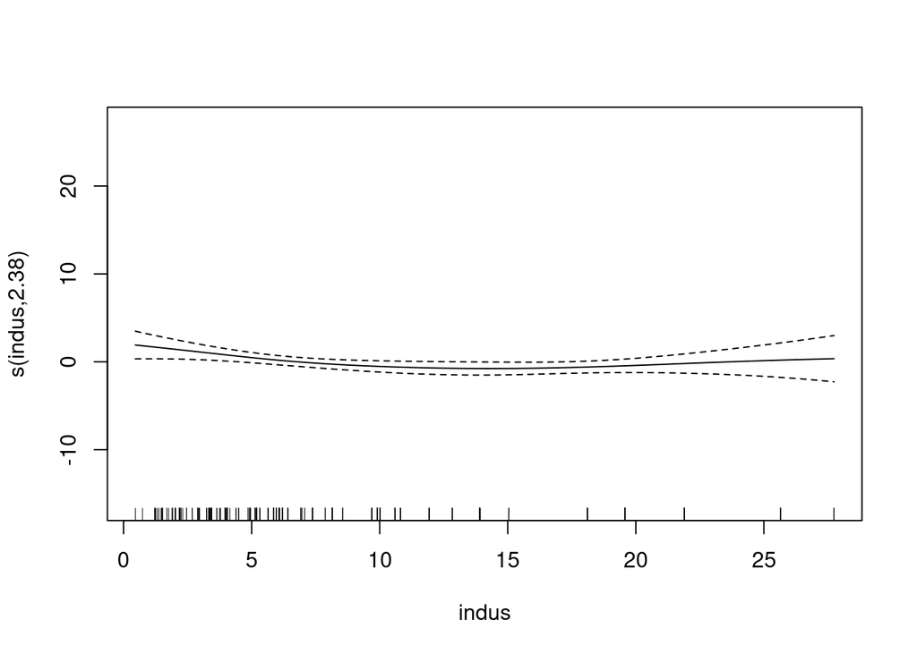

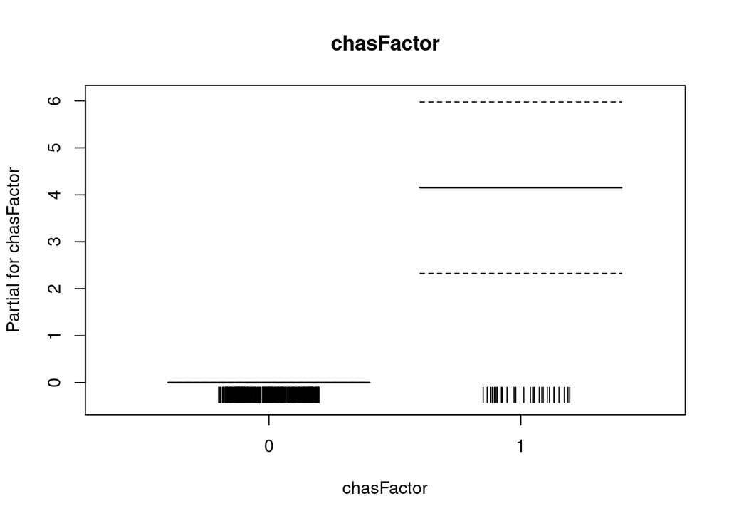

```r
plot(GAMmodel1, all.terms = TRUE)
```

#### Part c. - Fit a multiple linear regression model for predicting medv using lstat, indus and chas

```r
#Method 1: Fit a Linear Regression Model using lm()
LinRegModel <- lm(medv ~ lstat + indus + chasFactor, data = Boston)
summary(LinRegModel)
```

```
##
## Call:
## lm(formula = medv ~ lstat + indus + chasFactor, data = Boston)
##
## Residuals:
##     Min      1Q  Median      3Q     Max
## -14.369  -3.868  -1.252   1.846  25.855
##
## Coefficients:
##             Estimate Std. Error t value Pr(>|t|)
## (Intercept) 34.48456    0.58589  58.859  < 2e-16 ***
## lstat       -0.87637    0.04778 -18.340  < 2e-16 ***
## indus       -0.10981    0.04977  -2.207   0.0278 *
## chasFactor1  5.20406    1.07306   4.850 1.65e-06 ***
## ---
## Signif. codes:  0 '***' 0.001 '**' 0.01 '*' 0.05 '.' 0.1 ' ' 1
##
## Residual standard error: 6.072 on 502 degrees of freedom
## Multiple R-squared:  0.5668, Adjusted R-squared:  0.5642
## F-statistic: 218.9 on 3 and 502 DF,  p-value: < 2.2e-16
```

```r
#Method 2: Fit the Linear Regression Model using gam()
GAMmodel2 <- gam(medv ~ lstat + indus + chasFactor, data = Boston)
summary(GAMmodel2)
```

```
##
## Family: gaussian
## Link function: identity
##
## Formula:
## medv ~ lstat + indus + chasFactor
##
## Parametric coefficients:
##             Estimate Std. Error t value Pr(>|t|)
## (Intercept) 34.48456    0.58589  58.859  < 2e-16 ***
## lstat       -0.87637    0.04778 -18.340  < 2e-16 ***
## indus       -0.10981    0.04977  -2.207   0.0278 *
## chasFactor1  5.20406    1.07306   4.850 1.65e-06 ***
## ---
## Signif. codes:  0 '***' 0.001 '**' 0.01 '*' 0.05 '.' 0.1 ' ' 1
##
##
## R-sq.(adj) =  0.564   Deviance explained = 56.7%
## GCV = 37.159  Scale est. = 36.866    n = 506
```

#### Part d. - Does the GAM model perform better than a multiple linear regression model?

```r
#GAM
AIC(GAMmodel1)
```

```
## [1] 3095.405
```

```r
#MLR
AIC(GAMmodel2)
```

```
## [1] 3267.234
```

## Example - Assessing Predictive Performance using Validation Set Approach

#### Part a. - 80/20 training/validation split using a seed of 123

```r
set.seed(123)
trainInd <- sample(1:nrow(Boston), floor(0.8*nrow(Boston)))
set.seed(NULL)

Train <- Boston[trainInd, ]
Validation <- Boston[-trainInd, ]
```

#### Part b. - Build and compare 3 models

```r
#Cubic Spline Regression
model1 <- lm(medv ~ bs(x = lstat, degree =3, knots = quantile(Train$lstat, probs = c(.25,.5,.75))), data = Train)
model1Pred <- predict(model1, newdata = Validation)

model1RMSE <- sqrt(mean((Validation$medv - model1Pred)^2))
#Smoothing Spline
model2 <- smooth.spline(x = Train$lstat, y = Train$medv, cv = FALSE) # use GCV
model2Pred <- as.numeric(unlist(predict(model2, x = Validation$lstat)[[2]]))
model2RMSE <- sqrt(mean((Validation$medv - model2Pred)^2))
#GAM (smooth for lstat and indus, linear for chas)
model3 <- gam(medv ~ s(lstat) + s(indus) + chasFactor, data = Train)
model3Pred <- predict(model3, newdata = Validation)
model3RMSE <- sqrt(mean((Validation$medv - model3Pred)^2))
#GAM (linear model of lstat, indus, and chasFactor)
model4 <- gam(medv ~ lstat + indus + chasFactor, data = Train)
model4Pred <- predict(model4, newdata = Validation)
model4RMSE <- sqrt(mean((Validation$medv - model4Pred)^2))
# Regular linsar regression did the worst her.
```

[output not shown]